# Bayesian networks

### Intended Learning Outcomes

At the end of this part you will be able to:

- describe the concepts of conditional parameterisation and conditional independence,
- implement a naive Bayes model,
- calculate joint probabilities from Bayes networks,
- appreciate the use of Bayes networks in ecology and evolution.

If we want to represent a joint distribution $P$ over a set of binary-valued random variables $\{X_1, X_2, ..., X_N\}$ we would need to specify $2^n-1$ numbers.

Problems are:

- the explicit representation of the joint distribution is unmanageable,
- it is computationally expensive to store and manipulare it,
- it is impossible to acquire so many numbers from an elicited human expert,
- some numbers can be very small and hard to contemplate,
- we would need large amount of data to learn the joint distribution.

Solutions are:

1. use **independence properties** in the distribution and an **alternative parameterisation** to represent high-dimensional distributions more compactly,
2. use a combinatorial data structure - a directed acyclic graph - as a general-purpose modelling language.

### Conditional parameterisation

Consider the problem of assessing the demographic factors (e.g. birth vs. death rates, expansions vs. contractions) of a particular species of interest. It may be hard to quantify it directly but we have access to estimates of the population size which is informative on demographic factors although not fully indicative.

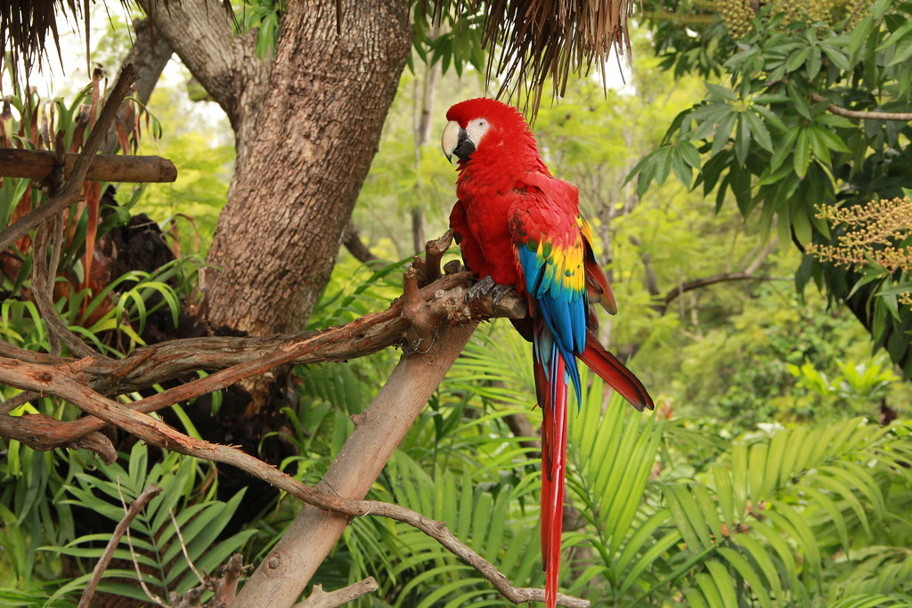

Our probability space is induced by two random variables *Demographic rate (D)* and *population Size (S)* .

We assume that both are binary-valued, so that

- $Val(D) = \{d^1, d^0\}$ which represent high ($d^1$) and low ($d^0$) demographic rate
- $Val(S) = \{s^1, s^0\}$ which represent high ($s^1$) and low ($s^0$) population size

Our joint distribution has four entries ($2^n$, but only $2^n-1$ are independent), for example

| D | S | P(D,S) |
| --- | --- | --- |
| $d^0$ | $s^0$ | 0.665 |
| $d^0$ | $s^1$ | 0.035 |
| $d^1$ | $s^0$ | 0.060 |
| $d^1$ | $s^1$ | 0.240 |

We can use the chain rule of conditional probabilities:

$P(X_1, ..., X_k) = P(X_1) P(X_2|X_1) \cdot \cdot \cdot P(X_k | X_1,...,X_{k-1})$

to represent our joint distribution as

$P(D,S) = P(D)P(S|D)$

Instead of specifying all entries of $P(D,S)$ we would specify in the form of $P(D)$ (the *prior distribution* over $D$) and $P(S|D)$ (the *conditional probability distribution* of $S$ given $D$).

| $d^0$ | $d^1$ |
| --- | --- |
| 0.7 | 0.3 |

| D | $s^0$ | $s^1$ |
| --- | --- | --- |
| $d^0$ | 0.95 | 0.05 |
| $d^1$ | 0.20 | 0.80 |

We are also representing the process in a way that is compatible with causality.

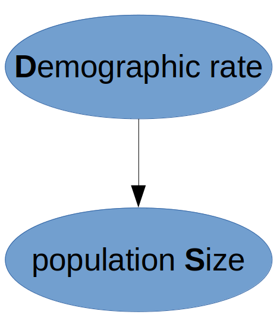

This Bayesian network has a node for each random variable with an edge representing the direction of the dependence in this model.

### Naive Bayes model

Assume we have access to some measure of the *Genetic diversity* ($G$) of our population of interest and $G$ takes on three values as

- $Val(G) = \{g^1, g^2, g^3\}$ which represent high ($g^1$), medium ($g^2$) and low ($g^3$) genetic diversity

We can exploit:

1. conditional parameterisation
2. conditional independence

For any reasonable $P(D,S,G)$ there are no independencies:

- $D$ is correlated to both $S$ and $G$
- $S$ and $G$ are not independent as, for instance, $P(g^1 | s^1) > P(g^2 | s^1)$

However $P$ satisfies a conditional independence property: if we know that a population has high demographic rate, a high population size no longer gives us information about the population’s genetic diversity.

$P(g | d^1, s^1) = P(g | d^1)$

$P \models P(S \perp G | D)$

We can write

$P(D,S,G) = P(S,G|D)P(D)$

but since

$P(S,G|D)=P(S|D)P(G|D)$

we have that

$P(D,S,G) = P(S|D)P(G|D)P(D)$

We factorise the joint distribution as a product of three conditional distributions.

The alternative parameterisation is more compact than the joint as we have three binomial distributions and two three-valued multinomial distributions (with a total of seven parameters instead of eleven).

| $d^0$ | $d^1$ |
| --- | --- |
| 0.7 | 0.3 |

| D | $s^0$ | $s^1$ |
| --- | --- | --- |
| $d^0$ | 0.95 | 0.05 |
| $d^1$ | 0.20 | 0.80 |

| D | $g^1$ | $g^2$ | $g^3$ |
| --- | --- | --- | --- |
| $d^0$ | 0.20 | 0.34 | 0.46 |
| $d^1$ | 0.74 | 0.17 | 0.09 |

This probabilistic model would be represented using a Bayesian network.

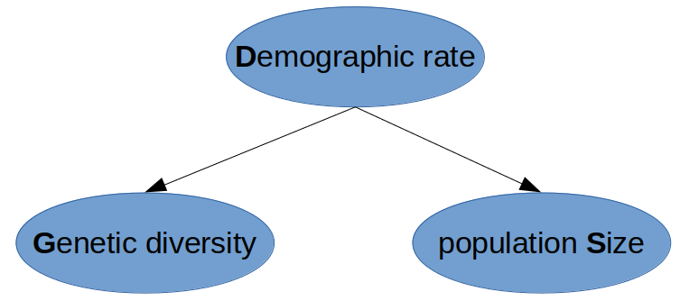

Modularity is another advantage of this representation.

This is an example of a general model called *naive Bayes model* which assumes that:

1. instances fall into one of a number of mutually exclusive and exhaustive *classes*
2. observed *features* are conditionally independent given the instance’s class

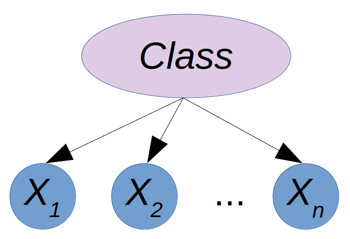

$(X_i \perp \textbf{X}|C)$ for all $i$

The model factorises as $P(C,X_1,...,X_n) = P(C)\prod_{i=1}^n P(X_i|C)$

**ACTIVITY**

What is the probability that a population has a low demographic rate, medium genetic diversity, low population size?

$P(d^0, g^2, s^0) = ?$

```r
# ...
```

The naive Bayes model is often chosen because of its simplicty and small number of parameters. However its strong assumptions may cause to overestimate the impact of certain evidence.

This model is typically used for classification with a confidence calculated by the ratio:

$$\begin{equation*}
\frac{P(C=c^1 | x_1,...,x_n)}{P(C=c^2 | x_1,...,x_n)} =
\frac{P(C=c^1)}{P(C=c^2)} \prod_{i=1}^n \frac{P(x_i | C=c^1)}{P(x_i |
C=c^2)}
\end{equation*}$$

**ACTIVITY**

What is the confidence that a population has a high demographic rate given that it has medium genetic diversity and high population size?

```r
# ...
```

### Bayesian networks

They build on the same intuitions as the naive Bayes model but they don’t require strong independence assumptions and are more flexible.

The core of Bayesian networks is a directed acyclic graph (DAG) $\mathcal{G}$ whose nodes are the random variables in our domain and whose edges correspond, intuitively, to direct influence of one node to another.

The graph $\mathcal{G}$ can be viewed as:

1. a data structure to represent a joint distribution compactly in a factorised way
2. a compact representation for a set of conditional independence assumptions about a distribution

These two views are equivalent.

Consider that the genetic diversity $G$ of a population depends not only by its demographic rate $D$ but also on *geographical Barriers* $B$ in its environment with

- $Val(B) = \{b^0, b^1\}$ which represent absence ($b^0$) and presence ($b^1$) of geographical barriers

Consider also that we want to assign a conservation status $C$ to said population with

- $Val(C) = \{c^0, c^1\}$ which represent threatened ($c^0$) and least-concerned ($c^1$) label.

We have five random variables:

- Demographic rate $D$, binary
- population Size $S$, binary
- Genetic diversity $G$, ternary
- Geographical Barriers $B$, binary
- Conservation status $C$, binary

The joint distribution has 48 entries.

The first component of a Bayesian network is its structure where each variable is a stochastic function of its parents.

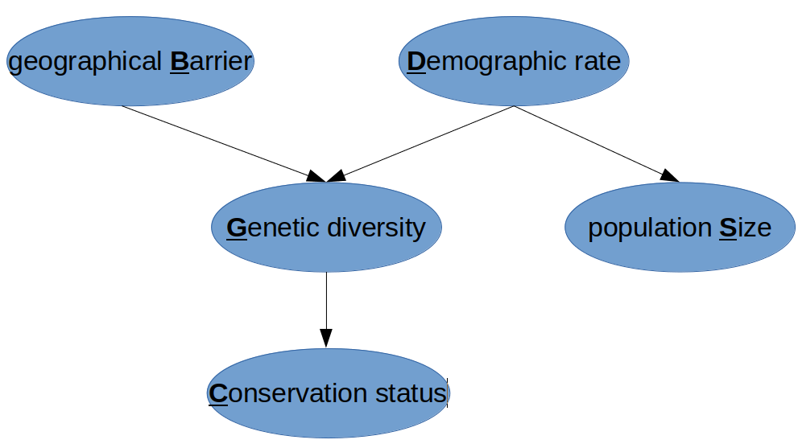

The second component is a set of *local probability models* .

| $b^0$ | $b^1$ |
| --- | --- |
| 0.6 | 0.4 |

| $d^0$ | $d^1$ |
| --- | --- |
| 0.7 | 0.3 |

| D | $s^0$ | $s^1$ |
| --- | --- | --- |
| $d^0$ | 0.95 | 0.05 |
| $d^1$ | 0.20 | 0.80 |

| D,B | $g^1$ | $g^2$ | $g^3$ |
| --- | --- | --- | --- |
| $d^0,b^0$ | 0.30 | 0.40 | 0.30 |
| $d^0,b^1$ | 0.05 | 0.25 | 0.70 |
| $d^1,b^0$ | 0.90 | 0.08 | 0.02 |
| $d^1,b^1$ | 0.50 | 0.30 | 0.20 |

| G | $c^0$ | $c^1$ |
| --- | --- | --- |
| $g^1$ | 0.1 | 0.9 |
| $g^2$ | 0.4 | 0.6 |
| $g^3$ | 0.99 | 0.01 |

The network structure together with its conditional probability distributions (CPDs) is a *Bayesian network* $\mathcal{B}$.

We can refer to this example as $\mathcal{B}^{species}$

We can use this data structure to calculate the probability of an event, e.g. $P(d^1, b^0, g^2, s^1, c^0)$

$P(d^1, b^0, g^2, s^1, c^0) = P(d^1) P(b^0) P(g^2 | d^1, b^0) P(s^1 | d^1) P(c^0 | g^2)$

```r
0.3*0.6*0.08*0.8*0.4
```

```
## [1] 0.004608
```

In general we have

$P(D,B,G,S,C) = P(D) P(B) P(G|D,B) P(S|D) P(C|G)$

which is an example of the *chain rule for Bayesian networks* .

### Intended Learning Outcomes

At the end of this part you are now able to:

- describe the concepts of conditional parameterisation and conditional independence,
- implement a naive Bayes model,
- calculate joint probabilities from Bayes networks,
- appreciate the use of Bayes networks in ecology and evolution.